# Commerical Analysis for Solar Industry

Jiadi Zhang

June 08, 2023

Abstract

The codes for the analysis are shown below: Importing libraries and data

```r
library(tidyverse)
library(car)
library(MASS)
```

```r
sdge = read_csv('SDGE_Interconnected_Project_Sites_2023-03-31.csv')
sce = read_csv('SCE_Interconnected_Project_Sites_2023-03-31.csv')
pge = read_csv('PGE_Interconnected_Project_Sites_2023-03-31.csv')
```

Data pre-processing

```r
df<-read_csv('CaliforniaIncomePopulation2.csv')

variable_list = c('Population.Density','Service.Zip','Total.Average.Usage','MedianIncome','Population','Total.System.Size')
features_list = c('Population.Density','Total.Average.Usage','MedianIncome','Population')

df = df[,variable_list]
df = df%>%drop_na()
```

In the codes below, we create index 1 for every zip code and checked its distribution.

Index 1 is the scaled difference between the actual solar/person of a zip code and the 95% quantile of solar/person in all zip codes. For index 1, we assume that the 95% quantile of solar/person is a realistic level of market saturation point for a local market.

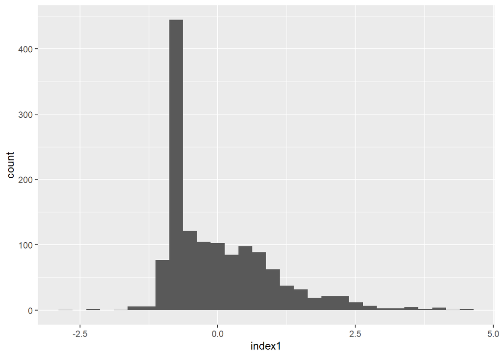

```r
df$system.per.person<-df$Total.System.Size/df$Population

value<-quantile(df$system.per.person, probs = 0.95)

df$potential1 = df$Population*value - df$Total.System.Size

df$index1 <- scale(df$potential1)

ggplot(data = df, aes(x=index1))+geom_histogram()
```

In the codes below, we create index 2.

Index 2 is the scaled difference between the actual solar/residual_annual_electric_usage of a zip code and the 95% quantile of solar/residual_annual_electric_usage in every zip code. For index 2, we assume that the real determinant of the amount of residential solar installed by a market is its residual electric usage, and that the 95% quantile of the current solar/residual_annual_electric_usage is a realistic level of market saturation point for a local market.

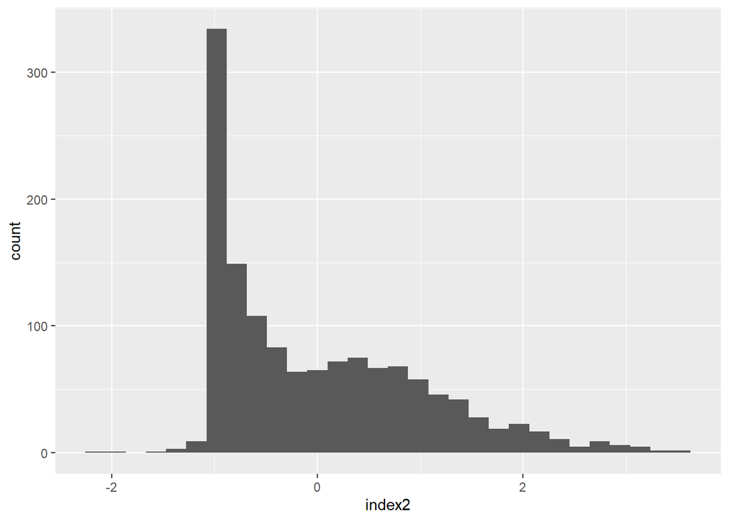

```r
df$system.per.usage<-df$Total.System.Size/df$Total.Average.Usage

value = quantile(df$system.per.usage, probs = 0.95)


df$potential2 = df$Total.Average.Usage*value- df$Total.System.Size

df$index2 <- scale(df$potential2)

ggplot(data = df, aes(x=index2))+geom_histogram()
```

In the codes below, we will generate the value of index 3 for every zip code. Index 3 is the difference between its actual solar installation level and its expected solar installation level based on its population density, population, electric usage, and median income. The expected solar installation level will be computed by a multiple-linear regression fitted based on its population density, population, electric usage, and median income data.

The outline of the codes for this section is below:

1. checking the distribution of the features
2. creating all the 2-degree and 1-degree interaction terms of the features
3. select the final feature through back AIC
4. fit a linear model with the final features
5. calculate the difference between the expected amount of solar system calculated by the model and the actual amount of solar system calculated by the model
6. standard scale the differences to get index 3

Step 1: checking the distribution of different features of zip codes and fitting the model with interaction variables

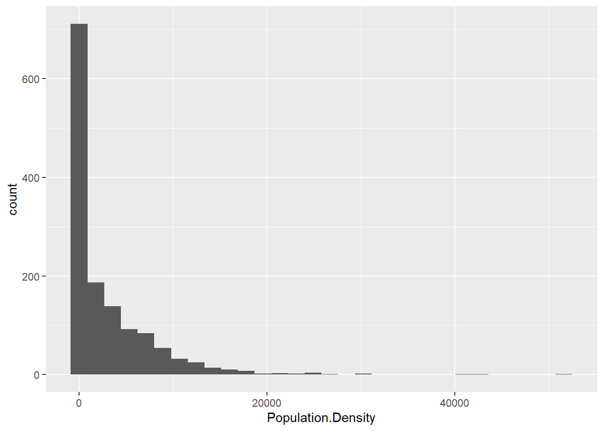

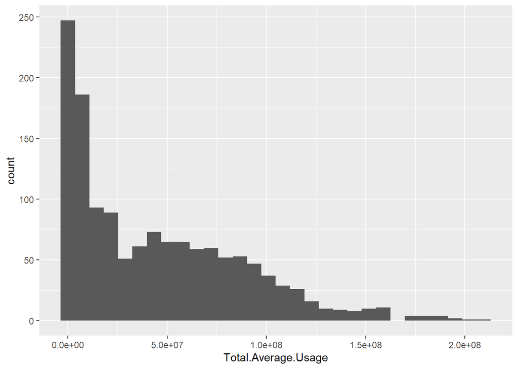

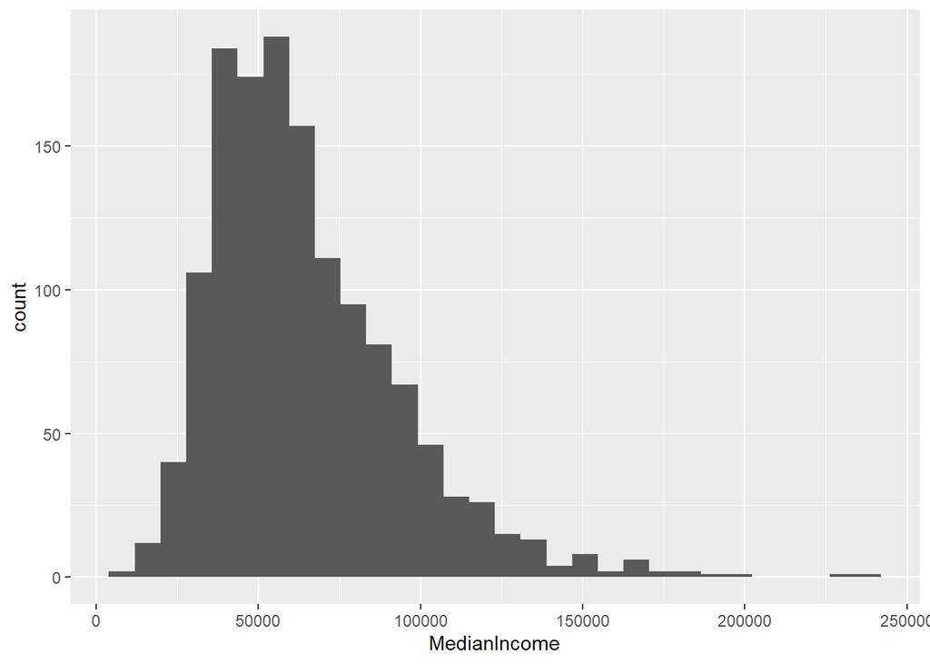

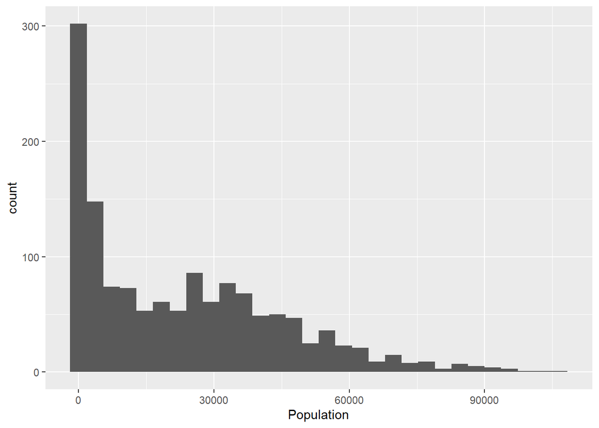

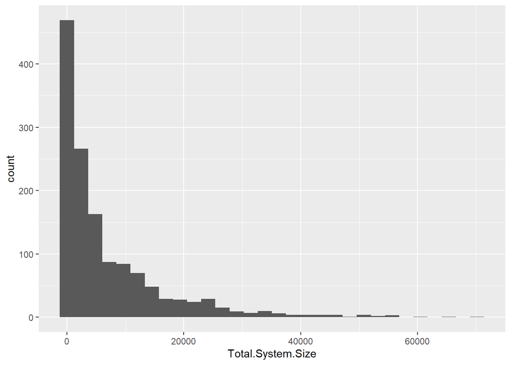

```r
scaled_df = as.data.frame(scale(df[,features_list]))
scaled_df = cbind(df[,c('Service.Zip','Total.System.Size')],scaled_df)


for (i in variable_list[variable_list !='Service.Zip']){
  temp_df = df[i]
  print(ggplot(data = temp_df, aes(x=temp_df[[i]]))+geom_histogram(bin=30) +xlab(i))
}
```

```r
#for (i in variable_list){
#  temp_df = df_temp[i]
#  print(ggplot(data = temp_df, aes(x=temp_df[[i]]))+geom_histogram(bin=30) +xlab(i))
#}

system.size.percentile.line = quantile(scaled_df$Total.System.Size, probs = 0.95)
density.percentile.line = quantile(scaled_df$Population.Density, probs = 0.98)


scaled_df = scaled_df%>%filter(Total.System.Size < system.size.percentile.line)

scaled_df = scaled_df%>%filter(Population.Density < density.percentile.line)

data_invest<-scaled_df%>%filter(Total.Average.Usage < -0.8)

write.csv(data_invest,'data_invest.csv')
```

Step 2:

1. Creating all possible 2-degree interaction terms.

```r
multiple_combinations <- data.frame(matrix(ncol = 0, nrow = nrow(scaled_df)))

for (i in features_list) {
  for (j in features_list) {
    multiple_col_name <- paste0(i, "_multiple_", j)
    multiple_combinations[multiple_col_name] <- scaled_df[i] * scaled_df[j]}}


interaction_df <- cbind(scaled_df,multiple_combinations)
```

step 3:

1. Creating the second sets of interactions terms.
2. using back AIC for feature selection and model fitting.
3. checking the validity of the model by checking the p-value, the R-squared, and the residual plot

```r
division_combinations <- data.frame(matrix(ncol = 0, nrow = nrow(scaled_df)))

# Iterate over the columns to compute all division combinations
for (i in features_list) {
  for (j in features_list) {
    division_col_name <- paste0(i, "_divided_by", j)
    division_combinations[division_col_name] <- scaled_df[i] / scaled_df[j]}}

# View the resulting data frame with division combinations

level2_df = cbind(interaction_df,division_combinations)


mod2<-lm(Total.System.Size ~ ., level2_df[, -which(names(level2_df) == "Service.Zip")])
final_model <- step(mod2, direction = "backward" )
```

```r
summary(final_model)
```

```
##
## Call:
## lm(formula = Total.System.Size ~ Population.Density + Total.Average.Usage +
##     MedianIncome + Population + Population.Density_multiple_Population.Density +
##     Population.Density_multiple_Total.Average.Usage + Population.Density_multiple_MedianIncome +
##     Total.Average.Usage_multiple_Total.Average.Usage + Total.Average.Usage_multiple_MedianIncome +
##     MedianIncome_multiple_Population + MedianIncome_divided_byPopulation.Density,
##     data = level2_df[, -which(names(level2_df) == "Service.Zip")])
##
## Residuals:
##      Min       1Q   Median       3Q      Max
## -15364.6  -1266.4    -69.2    695.1  16663.2
##
## Coefficients:
##                                                    Estimate Std. Error t value
## (Intercept)                                       6398.9124   159.4247  40.138
## Population.Density                               -3134.1990   243.1627 -12.889
## Total.Average.Usage                               6094.9065   221.6838  27.494
## MedianIncome                                       484.3436   110.2083   4.395
## Population                                         597.6866   213.8173   2.795
## Population.Density_multiple_Population.Density     538.2478   157.8311   3.410
## Population.Density_multiple_Total.Average.Usage  -1938.2058   169.7392 -11.419
## Population.Density_multiple_MedianIncome          -296.7748   159.5090  -1.861
## Total.Average.Usage_multiple_Total.Average.Usage  -297.8667   109.1946  -2.728
## Total.Average.Usage_multiple_MedianIncome         -704.0657   203.7251  -3.456
## MedianIncome_multiple_Population                   999.4740   246.2806   4.058
## MedianIncome_divided_byPopulation.Density            2.0375     0.8576   2.376
##                                                  Pr(>|t|)
## (Intercept)                                       < 2e-16 ***
## Population.Density                                < 2e-16 ***
## Total.Average.Usage                               < 2e-16 ***
## MedianIncome                                     1.20e-05 ***
## Population                                       0.005263 **
## Population.Density_multiple_Population.Density   0.000669 ***
## Population.Density_multiple_Total.Average.Usage   < 2e-16 ***
## Population.Density_multiple_MedianIncome         0.063040 .
## Total.Average.Usage_multiple_Total.Average.Usage 0.006463 **
## Total.Average.Usage_multiple_MedianIncome        0.000567 ***
## MedianIncome_multiple_Population                 5.25e-05 ***
## MedianIncome_divided_byPopulation.Density        0.017652 *
## ---
## Signif. codes:  0 '***' 0.001 '**' 0.01 '*' 0.05 '.' 0.1 ' ' 1
##
## Residual standard error: 3194 on 1264 degrees of freedom
## Multiple R-squared:  0.7529, Adjusted R-squared:  0.7508
## F-statistic: 350.2 on 11 and 1264 DF,  p-value: < 2.2e-16
```

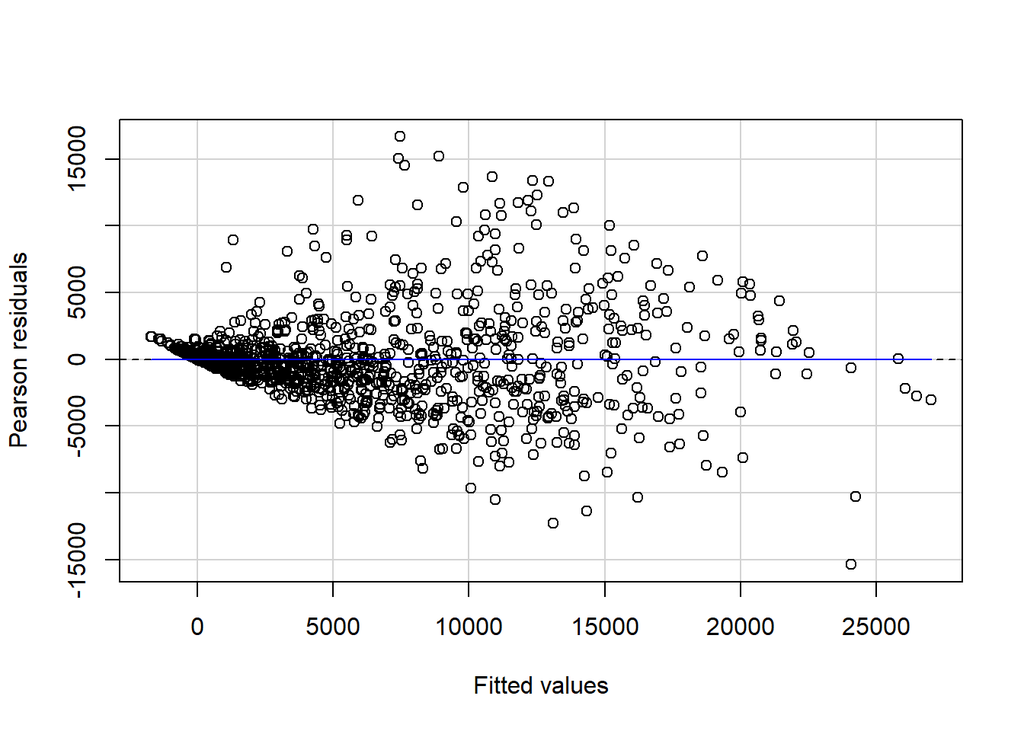

```r
residualPlot(final_model)
```

Checking the predicted values vs the true values

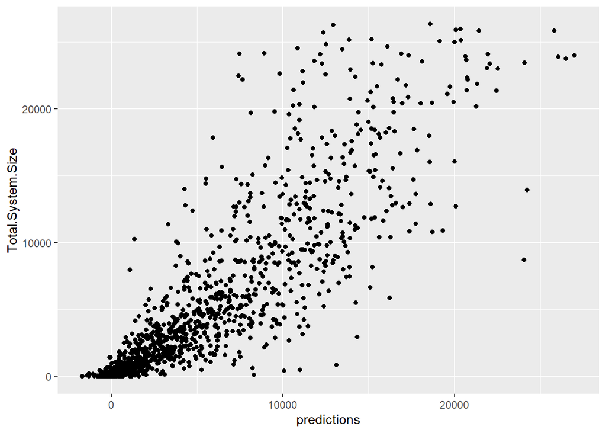

```r
level2_df$predictions<-predict(final_model, level2_df)

level2_df%>%ggplot(aes(x=predictions, y = Total.System.Size))+geom_point()
```

```r
level2_df$negative_residual<-(level2_df$predictions - level2_df$Total.System.Size)

indexed1 = merge(df,level2_df[,c('negative_residual','Service.Zip')],by.x = 'Service.Zip',by.y='Service.Zip')
```

The codes below generate index 4.

Index 4 indicates the difference between the actual amount of solar installed in a zip code and the average amount of solar installed in zip codes that are similar in terms of median income, electric usage, population density, and population.

The outline of the code is below:

1. categorize all zipcodes into clusters through k-means(feautes are , median income, electric usage, population density, population).
2. calculate the average amount of solar installed in every cluster.
3. calculate the difference between the actual solar and the cluster-average solar for every zip code.
4. standard scale the difference to get index 4

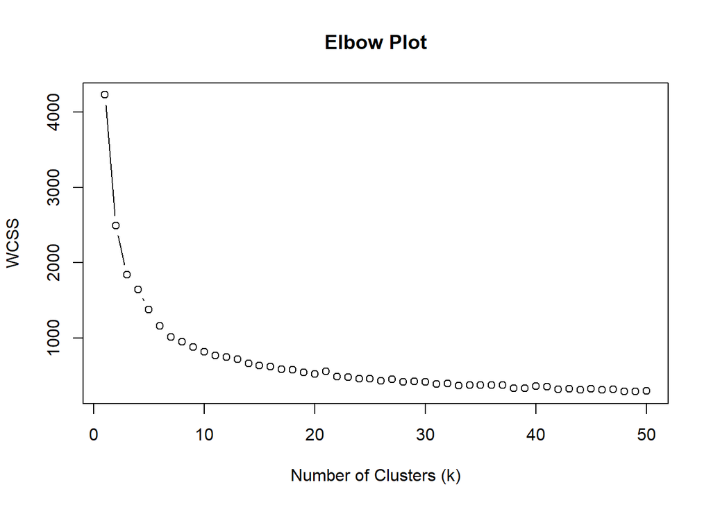

```r
cluster_frame<-as.data.frame(scaled_df[,features_list])
wcss <- numeric(length = 50)  # Initialize empty vector to store WCSS values

for (k in 1:length(wcss)) {
  kmeans_model <- kmeans(cluster_frame, centers = k)
  wcss[k] <- kmeans_model$tot.withinss
}

# Plot the elbow plot
plot(1:length(wcss), wcss, type = "b", xlab = "Number of Clusters (k)", ylab = "WCSS",
     main = "Elbow Plot")
```

```r
cluster_frame$clusters<-kmeans(cluster_frame, centers = 40)$cluster

cluster_frame2<-cbind(scaled_df[,c('Service.Zip','Total.System.Size')],cluster_frame)

cluster_frame2%>%group_by(clusters)%>%summarise(n=n())
```

| clusters | n |
| --- | --- |
| 1 | 11 |
| 2 | 43 |
| 3 | 46 |
| 4 | 29 |
| 5 | 79 |
| 6 | 33 |
| 7 | 27 |
| 8 | 14 |
| 9 | 67 |
| 10 | 28 |

[output cut: 30 more lines]

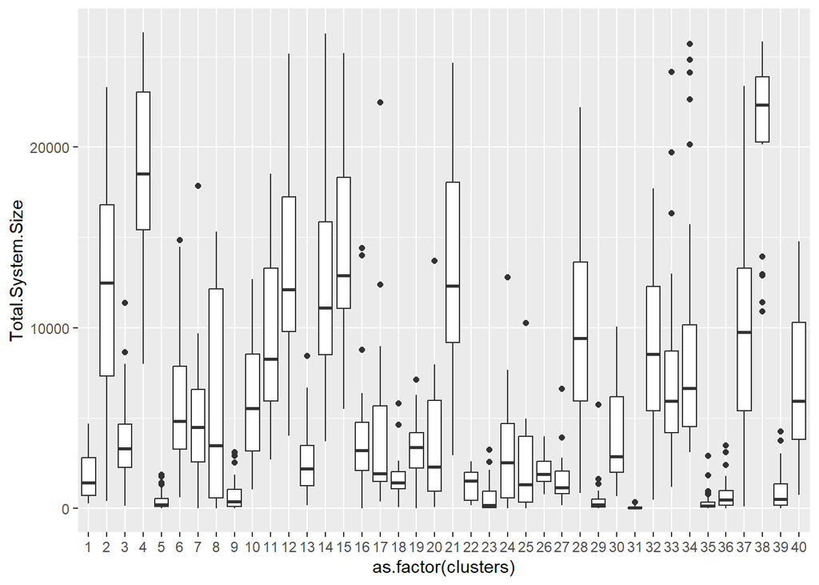

```r
cluster_frame2%>%ggplot(aes(x=as.factor(clusters),y = Total.System.Size))+geom_boxplot()
```

```r
potential3<-cluster_frame2%>%group_by(clusters)%>%summarise(Service.Zip,Total.System.Size,group_average=mean(Total.System.Size))%>%summarise(Service.Zip,negative_residual2 = group_average -  Total.System.Size)

indexed2 = merge(indexed1,potential3,by.x = 'Service.Zip',by.y='Service.Zip')
```

The codes below compare the indices and compute the counties that scored top 15 in all four indices.

We also check the distributions of different indices to check abnormality and the correlations between different indices

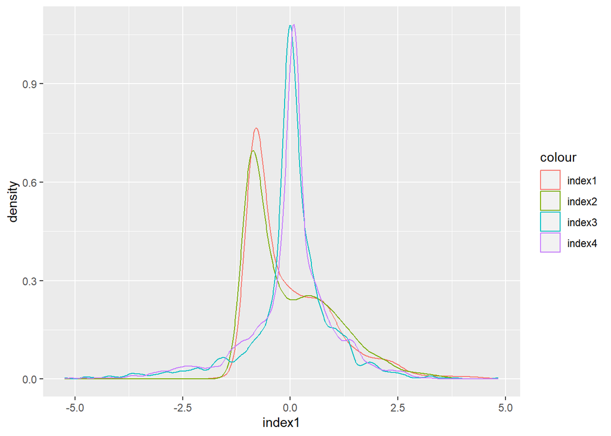

```r
indexed3 = indexed2[,c('Service.Zip','index1','index2','negative_residual','negative_residual2')]
indexed3$Service.Zip <- as.character(indexed3$Service.Zip)
indexed3[,c('index1','index2','negative_residual','negative_residual2')] <-scale(indexed3[,-which(names(indexed3) == "Service.Zip")])
colnames(indexed3) = c('Service.Zip','index1','index2','index3','index4')

indexed3%>%ggplot()+geom_density(aes(x=index1,color = 'index1'))+geom_density(aes(x=index2,color = 'index2'))+geom_density(aes(x=index3,color = 'index3'))+geom_density(aes(x=index4,color = 'index4'))
```

```r
cor(indexed3[,-which(names(indexed3) == "Service.Zip")])
```

```
##           index1     index2    index3     index4
## index1 1.0000000 0.77420066 0.1746046 0.16616648
## index2 0.7742007 1.00000000 0.2324817 0.09820902
## index3 0.1746046 0.23248173 1.0000000 0.85030269
## index4 0.1661665 0.09820902 0.8503027 1.00000000
```

```r
indexed3$index3_2_dif = indexed3$index3 - indexed3$index2
```

Finally, we scaling the index to county level and compute the counties with the highest potential level agreed by all 4 indices.

```r
california <- rbind(sdge,sce,pge)
california$`Service County`<- tolower(california$`Service County`)



#california%>%drop_na(`System Size DC`)%>%filter(`App Approved Date`>'2015-10-10')%>%group_by(`Service #County`, Monthly=floor_date(`App Approved Date`,unit = "4 months"))%>%summarise(total = sum(`System Size #DC`))%>%ggplot(aes(x=Monthly, y = total, color = `Service County`))+geom_line()




zip_code_and_counties<-california%>%group_by(`Service Zip`)%>%summarise(county = unique(`Service County`))

Zip_counties_indices<-merge(zip_code_and_counties,indexed3, by.x = 'Service Zip', by.y = 'Service.Zip', all.x = TRUE)%>%drop_na()

county_indices<-Zip_counties_indices%>%group_by(`county`)%>%summarise(index1 = sum(index1), index2 = sum(index2), index3  = sum(index3), index4 = sum(index4))

cor(county_indices[,-c(1)])
```

```
##           index1    index2    index3    index4
## index1 1.0000000 0.9587915 0.4060106 0.4330203
## index2 0.9587915 1.0000000 0.3661165 0.3628605
## index3 0.4060106 0.3661165 1.0000000 0.9869649
## index4 0.4330203 0.3628605 0.9869649 1.0000000
```

```r
index1_result<-county_indices%>%arrange(desc(index1))
index2_result<-county_indices%>%arrange(desc(index2))
index3_result<-county_indices%>%arrange(desc(index3))
index4_result<-county_indices%>%arrange(desc(index4))

index1_result[c(1:15),]$county[index1_result[c(1:15),]$county %in% index2_result[c(1:15),]$county & index1_result[c(1:15),]$county %in% index3_result[c(1:15),]$county & index1_result[c(1:15),]$county %in% index4_result[c(1:15),]$county]
```

```
## [1] "los angeles" "orange"      "alameda"     "san mateo"   "ventura"
## [6] "napa"
```